# Marine Ecological Modelling Global Climate Change

Jorge Assis, PhD // Centre of Marine Sciences, University of Algarve

## Biodiversity data

## Biodiversity data

Ecological niche models require georeferenced biodiversity occurrence data (e.g. species locations, which is the response or dependent variable). Such information are widely available in digital format (e.g., online repositories provide data on species distributions like GBIF).

```r
# read records
records <- read.csv("Data/dataBases/gbif.csv", sep = ";")

# display the DF structure
View(records)

# read a landmass polygon
world <- ne_countries(scale = "medium")
europeanExtent <- extent(-35, 45, 25, 55)
landmassEur <- crop(world, europeanExtent)
```

S4 // Biodiversity data in R

## Plot biodiversity occurrence data with R.

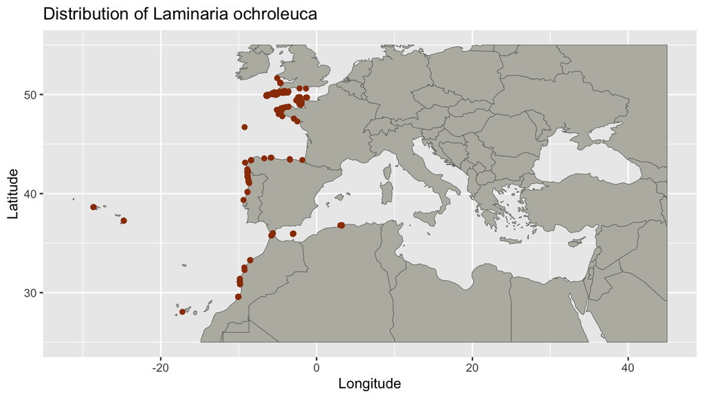

```r
ggplot() + geom_polygon(data = landmassEur, fill = "#B9B8B0", colour = "#707070", size = 0.2,
    aes(long, lat, group = group)) + geom_point(data = records, aes(decimalLongitude, decimalLatitude),
    color = "#9A3B04") + xlab("Longitude") + ylab("Latitude") + ggtitle("Distribution of Laminaria ochroleuca")
```

S4 // Biodiversity data in R

### Challenge 4.1

The main objective of this challenge is to **collect** and **plot** biodiversity records from iNaturalist - https://inaturalist.org/.

**Packages, data and functions to accomplish the challenge:**

source(“sourceFunctions.R”)  
“Data/vectorShapefiles/globalLandmass/world.shp”  
shapefile(path)  
read.csv(path)  
colnames(object)  
View(object)  
ggplot(object) or plot(object)

S4 // Biodiversity data in R

## Download bioiversity data with R

GBIF and OBIS contain R packages to access worldwide occurrence records from observations as well as museum records.

```r
# download GBIF records for a species (genus species)
recordsGBIF <- getOccurrencesGBIF("Laminaria ochroleuca")
nrow(recordsGBIF)
```

```
## [1] 1392
```

```r
colnames(recordsGBIF)
```

```
## [1] "Name"      "Locality"  "Lon"       "Lat"       "Depth"     "dateYear"
## [7] "dateMonth" "dateDay"
```

S4 // Biodiversity data in R

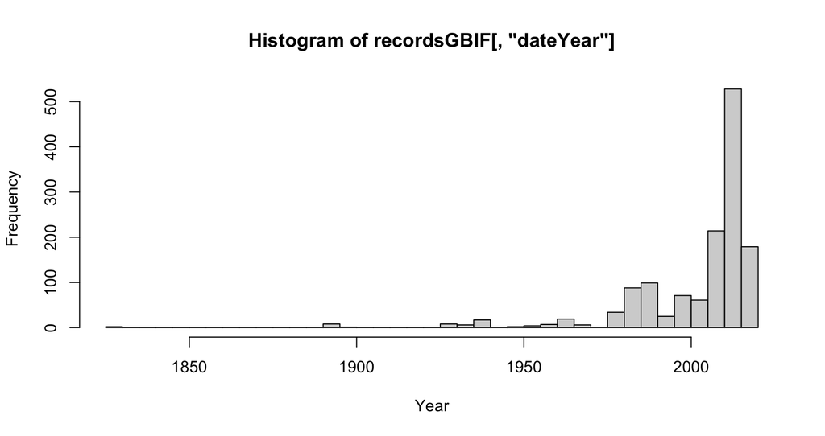

```r
# produce an histogram using the column referring to year data collection
hist(recordsGBIF[, "dateYear"], breaks = 50, xlab = "Year")
```

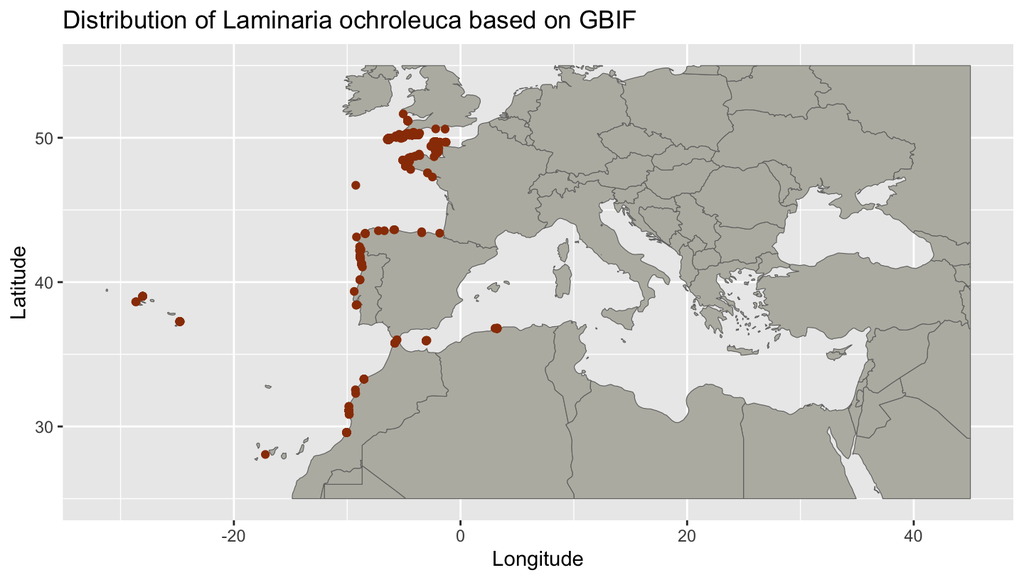

```r
# Plot the gbif biodiversity records.
ggplot() + geom_polygon(data = landmassEur, fill = "#B9B8B0", colour = "#707070", size = 0.2,
    aes(long, lat, group = group)) + geom_point(data = recordsGBIF, aes(Lon, Lat), color = "#9A3B04") +
    xlab("Longitude") + ylab("Latitude") + ggtitle("Distribution of Laminaria ochroleuca based on GBIF")
```

S4 // Biodiversity data in R

```r
# download GBIF records for a species (genus species)
recordsOBIS <- getOccurrencesObis("Laminaria ochroleuca")
nrow(recordsOBIS)
```

```
## [1] 242
```

```r
colnames(recordsOBIS)
```

```
## [1] "Name"      "Locality"  "Lon"       "Lat"       "Depth"     "dateYear"
## [7] "dateMonth" "dateDay"
```

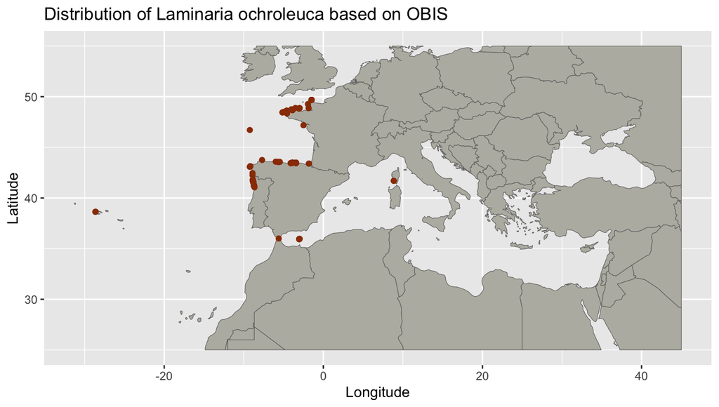

```r
# Plot the gbif biodiversity records.
ggplot() + geom_polygon(data = landmassEur, fill = "#B9B8B0", colour = "#707070", size = 0.2,
    aes(long, lat, group = group)) + geom_point(data = recordsOBIS, aes(Lon, Lat), color = "#9A3B04") +
    xlab("Longitude") + ylab("Latitude") + ggtitle("Distribution of Laminaria ochroleuca based on OBIS")
```

S4 // Biodiversity data in R

## Combining different sources of biodiversity data

When merging different data sources to obtain a unique dataset, column names must match!

```r
# Subset occurrences to get only coordinates
recordsGBIF <- recordsGBIF[, c("Lon", "Lat")]

# Subset occurrences to get only coordinates
records <- records[, c("decimalLongitude", "decimalLatitude")]

finalRecords <- rbind(recordsGBIF, records)
```

```
## Error in match.names(clabs, names(xi)): names do not match previous names
```

```r
colnames(records) <- c("Lon", "Lat")
finalRecords <- rbind(recordsGBIF, records)
nrow(finalRecords)
```

```
## [1] 2686
```

S4 // Biodiversity data in R

### Challenge 4.2

The main objetive of this challenge is to **collect** and **merge** biodiversity data from different sources (inaturalist and GBIF) for a species of your interest.

**Packages, data and functions to accomplish the challenge:**

source(“sourceFunctions.R”)  
“Data/vectorShapefiles/globalLandmass/world.shp”  
read.csv(path)  
shapefile(path)  
getOccurrencesGBIF(“species”)  
colnames(object)  
rbind(objet,object)  
ggplot(object) / plot(object)

S4 // Biodiversity data in R

## Data cleaning in R

Data ‘cleaning’ is particularly important for data sourced from data warehouses such as GBIF.

### Remove NA coordinates

```r
# get data from GBIF
records <- getOccurrencesGBIF("Laminaria ochroleuca")

# remove NA coordinates; Give the proper Longitude and Latitude column names
records <- removeNA(records, "Lon", "Lat")
```

```
## Removing 204 NA records
```

S4 // Biodiversity data in R

### Remove duplicate coordinates

```r
# remove duplicate coordinates; Give the proper Longitude and Latitude column names
records <- removeDuplicated(records, "Lon", "Lat")
```

```
## Removing 597 duplicated records
```

### Remove records on land

```r
# identify and remove records on land based on a polygon
records <- removeOverLand(records, "Lon", "Lat")
```

```
## Removing 414 records over Land
```

```r
# identify and remove records on land based on a distance (km) to shore [alternative]
records <- removeOverLandDist(records, "Lon", "Lat", dist = 9)
```

```
## Removing 0 records over Land
```

S4 // Biodiversity data in R

### Remove records outside known distributions

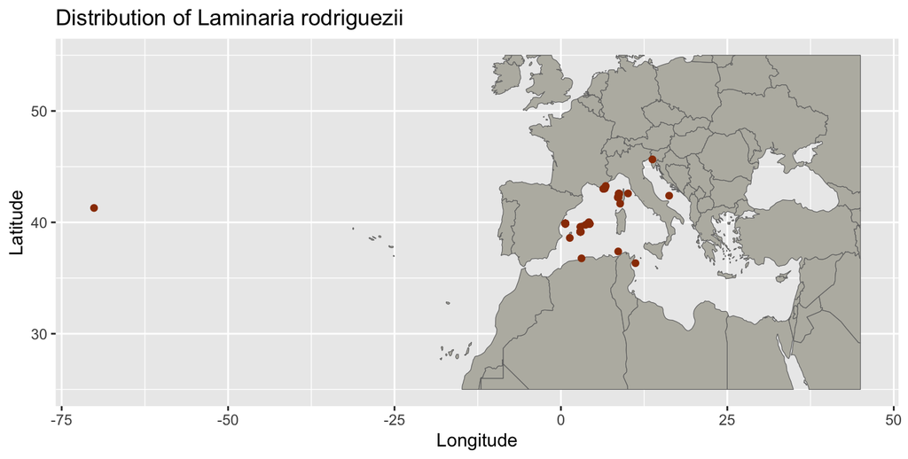

```r
# downloading records for a species that is endemic to the Mediterranean Sea
records <- getOccurrencesGBIF("Laminaria rodriguezii")

ggplot() + geom_polygon(data = landmassEur, fill = "#B9B8B0", colour = "#707070", size = 0.2,
    aes(long, lat, group = group)) + geom_point(data = records, aes(Lon, Lat), color = "#9A3B04") +
    xlab("Longitude") + ylab("Latitude") + ggtitle("Distribution of Laminaria rodriguezii")
```

S4 // Biodiversity data in R

Remove records outside known latitudinal and longitudinal distribution

- plot a polygon defining the region of interest;
- use function drawPoly() to choose the region where the species occur (press Esc. to exit);
- use function whichOverPolygon() to select the records within the drawn polygon.

```r
# plot a polygon defining the region of interest
plot(landmassEur)

# choose the region where the species occur
regionOfInterest <- drawPoly()

# select the records within the drawn polygon
pointsInRegion <- whichOverPolygon(records[, c("Lon", "Lat")], regionOfInterest)

# clip the records of occurrence
records <- records[pointsInRegion, c("Lon", "Lat")]
```

S4 // Biodiversity data in R

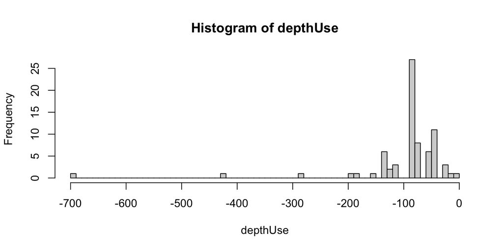

```r
# get a layer defining bathymetry
bathymetry <- raster("Data/rasterLayers/BathymetryDepthMean.tif")

# extract the depth of each occurrence record
depthUse <- extract(bathymetry, records[, c("Lon", "Lat")])

# plot an histogram
hist(depthUse, breaks = 50, na.rm = T)
```

S4 // Biodiversity data in R

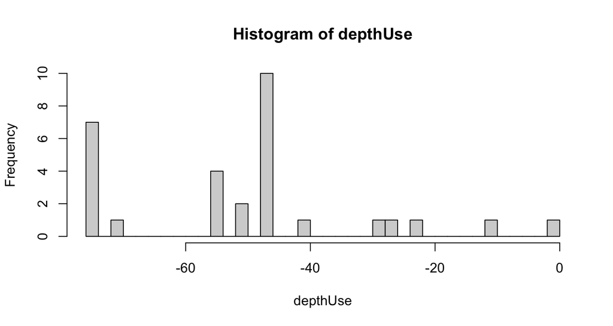

```r
# Remove records bellow 80m depth
records <- records[depthUse > -80, ]

# extract the depth of each occurrence and plot histogram
depthUse <- extract(bathymetry, records[, c("Lon", "Lat")])
hist(depthUse, breaks = 50, na.rm = T)
```

### Challenge 4.3

The main objetive of this challenge is to **collect** biodiversity data from GBIF and OBIS in R, **clean records** and produce a **plot**. For this challenge use the species Laminaria ochroleuca.

**Packages, data and functions to accomplish the challenge:**

Species: Laminaria ochroleuca;  
Information: The species only occur from morocco to Brittany (NE Atlantic), in the Azores and the Western Mediterranean Sea at maximum depths of 80m.  
Use Recipe #1  
1. get records with getOccurrencesGBIF() and getOccurrencesObis()  
2. remove NA coordinates  
4. remove duplicate coordinates with duplicated()  
5. identify records outside the know distibution (also depth)  
6. remove records on land  
8. plot records with plot() or ggplot()

S4 // Biodiversity data in R

### Challenge 4.4

The main objetive of this challenge is to **collect** biodiversity data from GBIF and OBIS in R and also from iNaturalist, **clean records**, produce a **plot** and **save** records for latter use. For this challenge use a species of your own interest.

**Packages, data and functions to accomplish the challenge:**

Species: your own interest  
Information: your own interest  
Use Recipe #1  
1. get records with getOccurrencesGBIF() and getOccurrencesObis()  
2. remove NA coordinates  
4. remove duplicate coordinates with duplicated()  
5. identify records outside the know distibution (also depth)  
6. remove records on land  
8. plot records with plot() or ggplot()  
9. Save records with write.table()

S4 // Biodiversity data in R

## References

Global change impacts on biodiversity. Available at: https://damariszurell.github.io/HU-GCIB

Copyright (c) Earth Lab. Available at: https://www.earthdatascience.org.

Open Science for Synthesis: Gulf Research Program Workshop. Available at: https://github.com/NCEAS/oss-lessons

Gimond, M. (2019) Intro to GIS and Spatial Analysis. Available at: https://mgimond.github.io/Spatial/